# Task. Measures of association

Data and statistics with R Research Methods

Jüri Lillemets

2019-09-11

# Categorical variables

## Load and understand data

For the tasks involving categorical variables use the data set *blackman_wheat.csv* in Moodle. The data set includes yield for conventional and semi-dwarf wheat varieties at 7 locations with low/high fertilizer levels. Download the data set to your computer, read it using `read.csv()` and then store it as a data frame.

```r
wheat <- read.csv('blackman_wheat.csv')
```

Next, use `str()` for an overview of the data frame.

```r
str(wheat)
```

```
## 'data.frame':    168 obs. of  5 variables:
##  $ gen  : Factor w/ 12 levels "Cap","Dur","Fun",..: 1 1 1 1 1 1 1 1 1 1 ...
##  $ loc  : Factor w/ 7 levels "Beg","Box","Cra",..: 3 3 1 1 6 6 7 7 2 2 ...
##  $ nitro: Factor w/ 2 levels "H","L": 2 1 2 1 2 1 2 1 2 1 ...
##  $ yield: int  321 411 317 429 364 464 408 434 419 492 ...
##  $ type : Factor w/ 2 levels "conv","semi": 1 1 1 1 1 1 1 1 1 1 ...
```

The variables are described as follows:

- `gen`, genotype
- `loc`, location
- `nitro`, nitrogen fertilizer, low/high
- `yield`, yield (g/m^2)
- `type`, type factor, conventional/semi-dwarf

## Research problem

```r
wheat$h.nitro <- wheat$nitro == 'H'
wheat$h.yield <- wheat$yield > mean(wheat$yield)
```

```r
conTab <- table(wheat$h.nitro, wheat$h.yield, dnn = c("Nitrogen", "Yield"))
conTab
```

```
##         Yield
## Nitrogen FALSE TRUE
##    FALSE    57   27
##    TRUE     34   50
```

## Odds

Odds of having high yield with high nitrogen vs having high yield without high nitrogen.

```r
sum(wheat$h.yield[wheat$h.nitro]) / sum(wheat$h.yield[!wheat$h.nitro])
```

```
## [1] 1.851852
```

## Risks

Probability of having high yield with high nitrogen

```r
sum(wheat$h.yield[wheat$h.nitro]) / sum(wheat$h.yield)
```

```
## [1] 0.6493506
```

# Continuous variables

## Load and understand data

To solve the following exercises use data set *engelstad_nitro.csv* available in Moodle. It contains corn yield response to nitrogen fertilizer for a single variety of corn at two locations over five years. Store this data in R workspace as you did with previous data set.

```r
corn <- read.csv('engelstad_nitro.csv')
```

Again, start by taking a look the data set with `str()`.

```r
str(corn)
```

```
## 'data.frame':    60 obs. of  4 variables:
##  $ loc  : Factor w/ 2 levels "Jackson","Knoxville": 1 1 1 1 1 1 1 1 1 1 ...
##  $ year : int  1962 1962 1962 1962 1962 1962 1963 1963 1963 1963 ...
##  $ nitro: int  0 67 134 201 268 335 0 67 134 201 ...
##  $ yield: num  46.5 59 71.9 73.1 74.5 75.5 29.3 55.2 77.3 88 ...
```

Below is a brief description of the variables.

- `loc`, location, 2 levels
- `year`, year, 1962-1966
- `nitro`, nitrogen fertilizer kg/ha
- `yield`, yield, quintals/ha

## Research problem

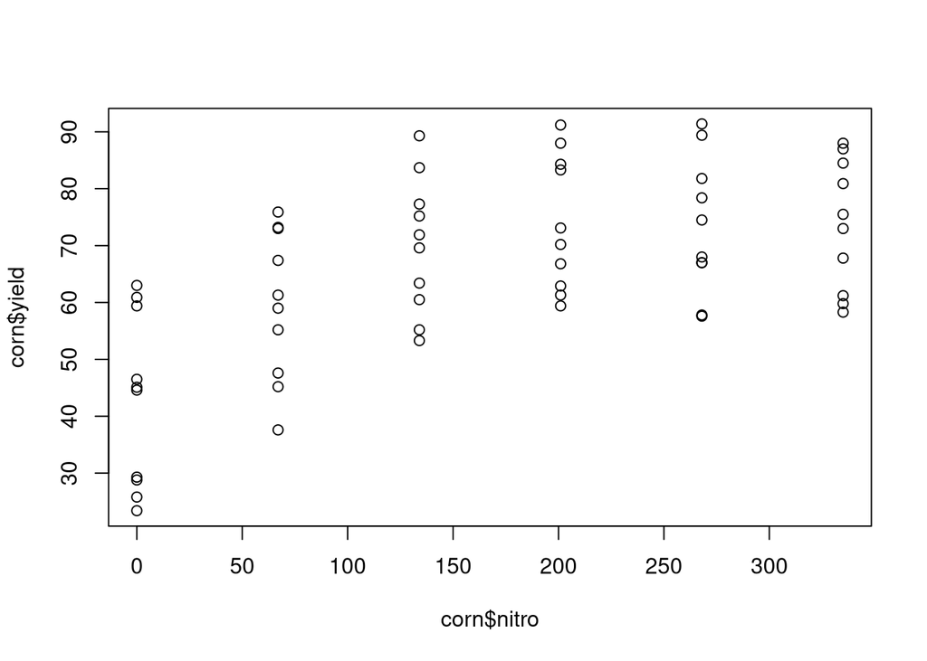

```r
plot(corn$nitro, corn$yield)
```

Actually discrete, so boxplot…

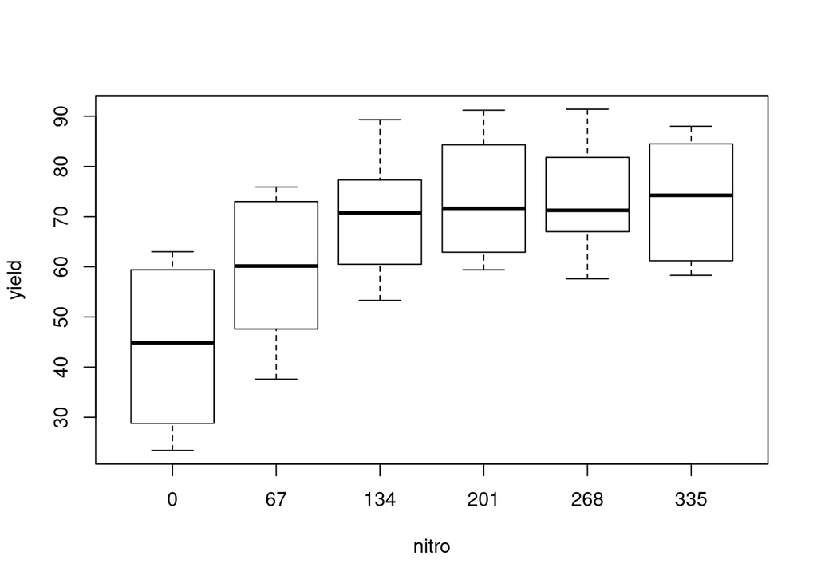

```r
boxplot(yield ~ nitro, corn)
```

## Correlation

```r
cor(corn$nitro, corn$yield, method = 'pearson')
```

```
## [1] 0.5908756
```

```r
cor(corn$nitro, corn$yield, method = 'spearman')
```

```
## [1] 0.5398918
```

> Which should we prefer, Pearson’s or Spearman coeficient of correlation?

## Heatmap

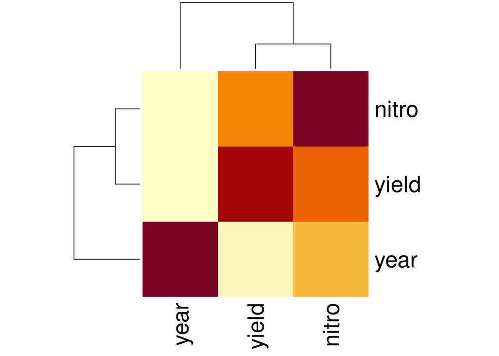

```r
corTab <- cor(corn[, c('year', 'nitro', 'yield')], method = 'spearman')
heatmap(corTab)
```